# BB 16S MB Final Analyses

Load required packages.

```r
require(phyloseq)
 require(parallelDist)
require(ggplot2)
  require(randomForest)
require(Boruta)
  require(phyloseq)
require(stats)
  require(dplyr)
require(readr)
  require(pheatmap)
require(tidyverse)
  require(micrUBIfuns)
```

[output not shown]

```r
require(circlize)
  require(phylosmith)
require(phangorn)
  require(gridExtra)
require(pairwiseAdonis)
  require(car)
require(phyloseq)
  require(microbiome)
require(EcolUtils)
  require(lme4)
require(lmerTest)
  require(DESeq2)
```

Load necessary files from Dada2 processing script.

```r
load("/Users/gordoncuster/Desktop/Git_Projects/BeeBread/Data/16S/DADA2outputs/dada2_outputs_16S_BeeBread_wtree.RData")
```

Read in metadata

```r
metadata<-read.csv("/Users/gordoncuster/Desktop/Git_Projects/BeeBread/Data/BB_sample-metadata.txt", sep = "\t")
rownames(metadata)<-metadata$X
metadata$Region_Site<-paste( metadata$Region, metadata$Site, sep = "")
metadata$Treatment_Site<-paste( metadata$Treatment, metadata$Site, sep = "")
```

Convert files to correct format for phyloseq object and then rename samples in OTU table to match the format of the metadata file. Create phyloseq object and root phylogenetic tree for usage with distance metrics (e.g., Unifrac).

```r
#assign object type to merge into phyloseq object
md<-sample_data(metadata)
otu<-otu_table(seqtab.nochim, taxa_are_rows = F)
tax_tab<-tax_table(taxa)
#check sample names of both otu table and metadata
#remove .fastq.gz from otu table names
sample_names(otu)<-str_split(sample_names(otu), pattern = ".fastq.gz", simplify = T) [,1]
#since they match, you can create the phyloseq object
bb16S_orig<-phyloseq(md, otu, tax_tab, fitGTR$tree)

#root tree for distance metrics like unifrac
set.seed(11)
phy_tree(bb16S_orig)<-root(phy_tree(bb16S_orig), sample(taxa_names(bb16S_orig), 1), resolve.root = TRUE)
is.rooted(phy_tree(bb16S_orig))
```

```
[1] TRUE
```

#Pre-processing. Rename OTU IDS to something more manageable. We save the ASCV sequences in case we need them later (e.g., BLASTN searches). Create Bacterial and Archaeal phyloseq objects, but first we remove Chloroplasts.

```r
#Extract original IDs for future reference.
seq_df_w_OTUID<-data.frame(OTUID = 1:ntaxa(bb16S_orig), Sequence = taxa_names(bb16S_orig))
taxa_names(bb16S_orig)<-paste("OTU_" , 1:ntaxa(bb16S_orig), sep = "")


#remove chloroplast
#978 chloroplast or mitochondrial taxa
bb16S_orig_nc<-subset_taxa(bb16S_orig, Family!= "Mitochondria" | is.na(Family) & Order!="Chloroplast" | is.na(Order))


#1337 bacterial taxa - 9 non-bacteria removed.
bb16S_bac<-subset_taxa(bb16S_orig_nc, Kingdom == "Bacteria")
#9 archaea
bb16S_arch<-subset_taxa(bb16S_orig_nc, Kingdom == "Archaea")
```

Remove control samples as there is only as single replicate of each.

```r
ps_wo_control<-subset_samples(bb16S_bac, Treatment != "none")
```

Examine rarefaction curves. Plateau in most samples under the 1.5k read mark.

[output not shown]

```r
set.seed(11)
sort(sample_sums(ps_wo_control))
summary(sample_sums(ps_wo_control))
sd(sample_sums(ps_wo_control))
#bb16S_bac_rarefy<-rarefy_even_depth(ps_wo_control, sample.size = 1100, rngseed = 14, trimOTUs = T)
#517 otus were removed during rarefaction.

#To move forward, we can hellinger transform and go from there.
#bb16S_bac_hellinger<-transform_sample_counts(ps_wo_control, function(x) sqrt(x / sum(x)))

#maximum liklihood point estimates
#bb16S_bac_ML<- transform_sample_counts(ps_wo_control, function(x) x / sum(x))

#clr transformation
#bb16S_bac_clr <- transform(ps_wo_control, transform = "clr")

#rarefaction iterative
#pull out otu_table and rarefy as per P. Schloss (2023)
bb16S_bac_rarefy_iter <- ps_wo_control
otu_tab <- data.frame(otu_table(bb16S_bac_rarefy_iter))
bb16S_bac_rarefy_iter_tab <- rrarefy.perm(x = otu_tab, sample = 1100, n = 1000, round.out = T)
#update otu table in phylsoeq object
otu_table(bb16S_bac_rarefy_iter) <-  otu_table(bb16S_bac_rarefy_iter_tab, taxa_are_rows = F)
#remove taxa with 0 counts across all rarefied samples
bb16S_bac_rarefy_iter <- prune_taxa(taxa_sums(bb16S_bac_rarefy_iter) > 0, bb16S_bac_rarefy_iter)
#left with 941 taxa and 72 samples

sample_sums(bb16S_bac_rarefy_iter)
#compare two permuted otu table to ensure it worked.
View(otu_table(ps_wo_control)[1:10, 1:10])
View(otu_table(bb16S_bac_rarefy_iter)[1:10, 1:10])
```

#Calculate mean abundance of dominant groups

```r
phy_ps <- tax_glom(bb16S_bac_rarefy_iter, taxrank = "Phylum")
#phylum counts
table(data.frame(tax_table(bb16S_bac_rarefy_iter))$Phylum)
phy_ps<- transform_sample_counts(phy_ps, function(x) x / sum(x))
phylum_df<-data.frame(otu_table(phy_ps))
rownames(tax_table(phy_ps)) == names(phylum_df)
names(phylum_df) <- tax_table(phy_ps)[,2]
apply(phylum_df, 2, mean)
apply(phylum_df, 2, sd)



order_ps <- tax_glom(bb16S_bac_rarefy_iter, taxrank = "Order")
#phylum counts
sort(table(data.frame(tax_table(bb16S_bac_rarefy_iter))$Order))
order_ps<- transform_sample_counts(order_ps, function(x) x / sum(x))
order_df<-data.frame(otu_table(order_ps))
rownames(tax_table(order_ps)) == names(order_df)
names(order_df) <- tax_table(order_ps)[,4]
apply(order_df, 2, mean)
apply(order_df, 2, sd)
```

#Alpha Diversity

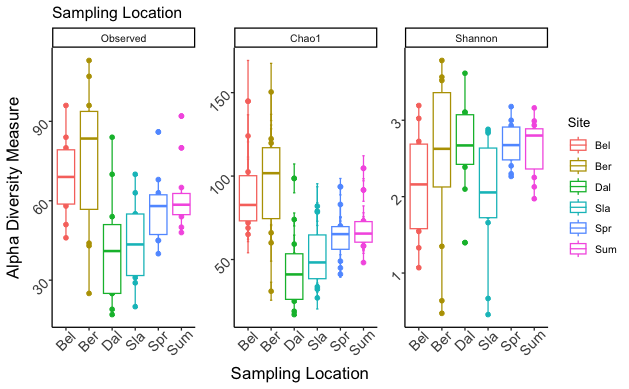

```r
sf2a <- plot_richness(bb16S_bac_rarefy_iter, x = "Site", measures = c("Shannon", "Observed", "Chao1"), color = "Site") + geom_boxplot() + ggtitle("Sampling Location") + theme_classic()  + xlab("Sampling Location")  + theme(axis.text=element_text(size=12, angle = 45, hjust = 0.75),
        axis.title=element_text(size=14))

sf2b <- plot_richness(bb16S_bac_rarefy_iter, x = "Site", measures = c("Shannon", "Observed", "Chao1"), color = "Treatment") + geom_boxplot() + ggtitle("Sampling Location by Treatment") + theme_classic() + ylab("") + xlab("Sampling Location") +theme(axis.text=element_text(size=12, angle = 45, hjust = 0.75),
        axis.title=element_text(size=14))

sf2c <-plot_richness(bb16S_bac_rarefy_iter, x = "Site", measures = c("Shannon", "Observed", "Chao1"), color = "Timepoint") + geom_boxplot() + ggtitle("Sampling Location by Sammpling Time") + theme_classic() + xlab("Sampling Location")  +theme(axis.text=element_text(size=12, angle = 45, hjust = 0.75),
        axis.title=element_text(size=14))

sf2d <-plot_richness(bb16S_bac_rarefy_iter, x = "Timepoint", measures = c("Shannon", "Observed", "Chao1"), color = "Treatment") + geom_boxplot() + ggtitle("Treatment by Sampling Time") + theme_classic() + ylab("") + xlab("Sampling Timepoint")  +theme(axis.text=element_text(size=12, angle = 45, hjust =0.75),
        axis.title=element_text(size=14))

sf2a
```